# Hatchery Tagging to Estimate pHOS Using IPTDS Detections

Kevin See

Biomark, Inc.  
Kevin.See@biomark.com

Mike Ackerman

Biomark, Inc.  
Mike.Ackerman@biomark.com

February 18, 2020

# Introduction

The Dam Adult Branch Occupancy Model (DABOM) is currently used to estimate adult escapement of natural origin spring/summer Chinook salmon *Onchorhynchus tshawytscha* and steelhead *O. mykiss* into watersheds and populations of the Snake River Basin (SRB). Escapement estimates are made based on the tagging of a random sample of adults at Lower Granite Dam (LGR) and the subsequent detection of those adults at instream PIT tag detection systems (IPTDS) throughout the SRB. DABOM could also be used to generate estimates of hatchery escapement to various locations as well, which would be useful for estimating hatchery abundance in natural areas and the proportion of hatchery origin spawners (*pHOS*). Doing so, with reasonable precision, may require a random sample (or similar) of adult hatchery fish also be PIT tagged at LGR. Here, we wish to determine expected levels of precision for *pHOS* given current levels of PIT tagging in the SRB, and further, determine the additional tagging, expressed as a tagging rate or number of tags, required in hatchery adults at LGR to achieve unbiased estimates of hatchery escapement and *pHOS* with reasonable levels of precision (e.g., coefficient of variation [CV] of $\leq$ 15%).

Simultaneously estimating escapement of hatchery origin (HOR) and natural origin (NOR) adults to IPTDS locations throughout the SRB based on PIT tagging at LGR is a trivial extension of the DABOM model. Factually, the previous and existing instance of the DABOM model was developed for the upper Columbia River (upstream of Priest Rapids Dam), which capitalized on the same sampling assumptions applied to natural origin escapement past LGR. However, for multiple reasons (ergonomic limitations at LGR, political considerations, ethical concerns), the random sampling and PIT tagging of HOR adults (specifically ad-clipped adults) at LGR has been precluded. Notably, given trap operations at LGR, HOR adults are trapped, anesthetized, weighed, and measured at the same rate as NOR - a function of “trap rate” constituting a fraction of every hour wherein adults in the ladder are bypassed to the trap. Thus, it is arguable that implantation of a PIT tag constitutes a significantly greater offense to captured hatchery adults.

Importantly, NOR and HOR refer to the origin of Chinook salmon or steelhead born in the natural or hatchery environment, respectively. Related, three phenotypic origins of adult Chinook salmon and steelhead are identified at LGR and include wild (W), hatchery ad-intact (HNC), and hatchery ad-clipped (H). NOR includes only W adults whereas HOR includes both the HNC and H groups despite HNC individuals often being phenotypically W. Currently, all ad-intact fish are systematically PIT tagged at LGR which includes both the W and HNC origins i.e., some HOR adults are currently tagged at LGR, but we need to consider differential tagging rates between HNC and H adults when evaluating the precision of *pHOS* given current levels of PIT tagging.

Unbeknownst to the proposal for this evaluation, a condition of the Hatchery and Genetics Management Plan (HGMP) required the operation of IDFG HOR steelhead production to conduct a study on HOR contributions to NOR populations. Thusly, IDFG and NOAA Fisheries endeavored to compile and estimate straying of HOR steelhead upstream of LGR.

This document seeks to begin collaboration between IDFG, NOAA Fisheries, and Biomark, Inc. to:

- Capitalize on existing progress on stray rates, and
- Advance statistical modeling to determine whether *pHOS* estimates can be reliably prosecuted by adult HOR PIT tagging at LGR.

In its developed form, the DABOM model includes escapement for NOR and HOR adult salmonids. Demonstrably, the DABOM is fully functional for multiple populations of spring/summer Chinook salmon and steelhead upstream of LGR. The performance of DABOM in the upper Columbia River (above Priest Rapids Dam) strongly suggests that the model can be reliably extended to HOR adults in the Snake River. Contents of this document, including findings, will be reported as part of a Final (Annual) Progress Report for Bonneville Power Administration (BPA) project 2019-006-00.

## Objectives

This assessment aims to determine the number or tagging rate of HOR adults at LGR necessary to determine *pHOS* across watersheds or populations of SRB steelhead estimated by the DABOM model (and supported by the operation of IPTDS maintained and operated under BPA project 2018-002-00) and with “reasonable” uncertainty (e.g., CV $\leq$ 15%). As a natural extension, we may also explore additional effort necessary to estimate *pHOS* in watersheds or populations of interest for Chinook salmon. Our objectives are as follows:

1. Determined expected CVs for current estimates of *pHOS* that could be generated for locations or populations in the SRB given current levels of PIT tagging. Current tagging includes:
- 1A. Individuals tagged within hatchery smolt releases, and
- 1B. Ad-intact hatchery (HNC) adults that are systematically PIT tagged at LGR to evaluate abundance and composition at LGR (e.g., Camacho et al. (2017)) and at IPTDS (e.g., Orme and Kinzer (2018)).
2. Determine additional tagging at LGR of ad-clipped adult HOR fish that would allow reasonable estimates of *pHOS*.

Because *pHOS* is a proportion, defined between 0 and 1, we feel CV is not the appropriate way to measure the precision. When *pHOS* is near 0 or 1, by definition the standard error of *pHOS* will be small. However, if *pHOS* is also very small, the CV will be large, since we are dividing by a small number, even if the standard error is still quite small (and therefore reasonable). Therefore, we believe a better definition of “precise estimate of pHOS” would be to define a standard error threshold, rather than a CV threshold. We explored several standard error thresholds, and believe further discussion with management agencies is warranted to settle on one.

# Methods

### Section 1. Expected precision of *pHOS* given current PIT tagging of hatchery smolt releases

Here, our aim is to evaluate the expected precision (CV) of *pHOS* using observations of individuals tagged within hatchery smolt releases and expansion values (inverse of tagging fraction) for those releases.

$$\hat{N_{h}} = \sum_{r=1}^{n}{n_r} * {\psi_{r}}$$
where $\hat{N_{h}}$ is the HOR abundance, $n_r$ is the number of observations of HOR individuals from release $r$ and $\psi_r$ is the expansion value for release $r$. HOR escapement to a given location can then be combined with estimates for NOR escapement from DABOM to estimate *pHOS* with uncertainty.

$$p_{HOS} = \frac{\hat{N_h}}{\hat{N_h} + \hat{N_n}}$$
where $\hat{N_{n}}$ is the NOR abundance. Importantly, DABOM requires a random sample of tagged individuals (e.g., at the adult trap), and thus, we cannot generate abundance estimates in the DABOM model using juvenile tagging; hence, the tag expansion approach. In other words, we need to expand the number of hatchery observations from each release group by the tagging fraction for that release groups and then sum across groups, and further, account for the detection probability of IPTDS sites within a location. Note that in this scenario we don’t need to account for differential survival among groups; we are only interested in tagging fractions within groups as long as we are willing to assume equal survival between tagged and untagged smolts.

#### Approach

The IDFG provided us with tagging fraction (i.e., expansion factor) information by brood year (BY), rearing hatchery, and mark type (H vs. HNC) for steelhead hatchery releases within Idaho from BY2013-2018. In addition, we have interrogation data and abundance estimates for wild steelhead populations available through spawn year (SY) 2019. Hatchery steelhead in Idaho are always released and emigrate to the ocean as 1 year olds. Using SY2019 hatchery adults as an example, those adults would have entered the Columbia River to initiate their spawning run during summer 2018; and thus 1-ocean adults would have emigrated to the ocean in 2017 (hence BY2016) and 2-ocean adults would have emigrated in 2016 (BY2015). Following this logic, we can consider the following BY smolt releases for each adult SY:

- SY2019: 1-ocean = BY2016, 2-ocean = BY2015
- SY2018: 1-ocean = BY2015, 2-ocean = BY2014
- SY2017: 1-ocean = BY2014, 2-ocean = BY2013

And thus, the earliest SY we can consider is 2017 as their 2-ocean adults originate from BY2013.

##### Locations

A recent assessment by See et al. (2019) identified steelhead TRT populations or locations containing IPTDS that can be used to estimate wild population abundance. We then performed a PTAGIS query for locations evaluated there, and in addition, queried for hatchery adult observations in the Lochsa, Selway, and North Fork Salmon rivers (areas with particular management interest where IPTDS have recently been installed) from smolt releases. Table 1 summarizes TRT populations and interrogation sites for which we queried observations of hatchery adults during SY2017-2019. The following constraints were placed on our PTAGIS query:

- Species: Steelhead
- Rear: Hatchery
- Last Obs Date/Time: 07/01/2017 - 06/30/2019
- Obs Site: In Table 1

Table 1: Steelhead TRT populations and interrogation sites for which we queried interrogation of hatchery adults during spawn years 2017-2019.

| TRT | Name | SiteID |
| --- | --- | --- |
| CRLMA-s | Clearwater River lower mainstem | CLC, HLM, JUL, KHS, LAP, MIS, PCM, SWT, WEB |
| CRLOC-s | Lochsa River | LRL, LRU |
| CRLOL-s | Lolo Creek | LC1, LC2 |
| CRSEL-s | Selway River | SW1, SW2 |
| CRSFC-s | South Fork Clearwater River | CRT, RRT, SC1, SC2 |
| GRJOS-s | Joseph Creek | JOC |
| GRLMT-s | Grande Ronde River lower mainstem tributaries | WEN |
| GRUMA-s | Grande Ronde River upper mainstem | CCW, UGR, UGS |
| GRWAL-s | Wallowa River | WR1, WR2 |
| IRMAI-s | Imnaha River | BSC, CMP, COC, CZY, IML, IR1, IR2, IR3, IR4, IR5 |
| MFBIG-s | Big, Camas, and Loon Creek | TAY |
| SFMAI-s | South Fork Salmon River | ESS, KRS, STR, YPP |
| SFSEC-s | Secesh River | ZEN |
| SNASO-s | Asotin Creek | ACB, ACM, AFC, CCA |
| SRLEM-s | Lemhi River | 18M, AGC, BHC, BTL, BTM, BTU, CAC, CRC, HEC, HYC, KEN, LB8, LBS, LCL, LLR, LLS, LRW, WPC |
| SRNFS-s | North Fork Salmon River | NFS |
| SRPAN-s | Panther Creek | PCA |
| SRUMA-s | Salmon River upper mainstem | RFL, STL, VC1, VC2, YFK |

Next, we filtered the above results from the PTAGIS query to only include the following observations:

- Mark Site Code Value: From Snake River hatcheries for which we have tagging fraction data for BY2013-2018 (i.e., CLWH, DWOR, HAGE, MAVA, NISP).
- Mark Year: Excluded marks that occurred prior to 2013. This includes filtering “orphan” tags.
- Last Obs Time - Mark Year < 1: In many cases, the mark year was less than 1 year prior to the final IPTDS observation. These observations are presumably from hatchery smolt releases and were removed.
- Spawn Year - Brood Year = 3 or 4: Returning adult hatchery steelhead should be 3 (‘A-run’) or 4 (‘B-run’) years old. We excluded any observations where this was not the case.

And finally, for each observation, personnel from the IDFG identified whether each tag was from an RAL or RTR release, and for RAL fish, the appropriate expansion value. RTR observations were ignored. Descriptions of RTR vs. RAL are as follows:

- RTR (“Return-to-River”): A sort-by-code designation for smolts that will automatically be returned to the river when detected at a dam, when other fish may be getting transported. They do not represent the release group at-large, therefore represent only themselves with an expansion value of “1”.
- RAL (“Run-at-Large”): A sort-by-code designation for smolts that will be transported or returned to the river in accordance with the protocol at the dam when they are detected. They represent the release group with a tagging rate that excludes any smolts that have an RTR tag in them. The expansion value of RAL tagged fish is the inverse of the tag rate.

Table 2: The number of observations of adult hatchery steelhead by location, spawn year, and mark site.

| TRT | Spawn Year | CLWH | DWOR | HAGE | MAVA | NISP | Total |
| --- | --- | --- | --- | --- | --- | --- | --- |
| CRLMA-s | 2017 | 1 | - | - | - | - | 1 |
| CRLOL-s | 2017 | - | 14 | - | - | - | 14 |
| CRLOL-s | 2018 | - | 6 | - | - | - | 6 |
| CRLOL-s | 2019 | - | 2 | - | - | - | 2 |
| CRSFC-s | 2017 | 103 | 11 | - | - | - | 114 |
| CRSFC-s | 2018 | 25 | 7 | - | - | - | 32 |
| CRSFC-s | 2019 | 66 | 16 | - | - | - | 82 |
| IRMAI-s | 2018 | - | - | - | 2 | - | 2 |
| MFBIG-s | 2018 | - | - | 1 | - | - | 1 |
| MFBIG-s | 2019 | - | - | 1 | - | - | 1 |
| SRLEM-s | 2017 | - | - | - | 2 | - | 2 |
| SRLEM-s | 2018 | - | 1 | - | 6 | 1 | 8 |
| SRNFS-s | 2018 | - | - | - | 2 | - | 2 |
| SRUMA-s | 2017 | - | - | 3 | 8 | - | 11 |
| SRUMA-s | 2018 | - | - | 17 | 1 | - | 18 |
| SRUMA-s | 2019 | - | - | 2 | 2 | - | 4 |

### Section 2. Expected precision of *pHOS* given current systematic PIT tagging of HNC adults at LGR

Next, we evaluated the expected precision (CV) of *pHOS* estimates given current PIT tagging rates of ad-intact adults, both wild (W) and hatchery (HNC) at LGR. This leverages the fact that all ad-intact adults trapped at LGR are already implanted with a PIT tag. Estimates of wild adult abundance across select TRT populations and locations in the SRB are already available from DABOM. Here, we will re-run DABOM for HNC individuals for SY 2017 through 2019 to get HNC abundance estimates for locations and populations where we already report W abundance using DABOM. The HNC and W abundance estimates, at the same spatial scales, can then easily be combined to estimate *pHOS* with uncertainty.

This evaluation ignores ad-clipped H adults, but is effective for estimating *pHOS* among ad-intact individuals and may be of particular interest for supplementation locations (e.g., South Fork Clearwater steelhead). Unfortunately, it seems there is no easy way to combine juvenile smolt release tagging (tag expansion approach) and adult tagging information at LGR (DABOM model, transition probability approach) to estimate hatchery abundance and *pHOS* using IPTDS observations.

### Section 3. Expected precision of *pHOS* by adding tagging of ad-clipped hatchery (H) adults at LGR

Finally, we evaluated the expected precision (CV) of *pHOS* estimates given additional (theoretical) tagging of ad-clipped hatchery (H) adults at LGR using a simulation approach. Here, again, we must ignore PIT tagged hatchery smolt releases and the tag expansion approach as the DABOM model is reliant on systematic tagging of the adult return. First, we demonstrate how an estimate of *pHOS* can be generated under the DABOM framework.

#### Mathematical Reasoning

The estimate of *pHOS* at any branch $i$ in the DABOM model can be written as

$$\hat{pHOS_i} = \frac{\mu_{h,i}}{\mu_{h,i} + \mu_{w,i}}$$

where $\mu_{h,i}$ and $\mu_{w,i}$ are the estimates of hatchery and wild fish who have escaped to spawn in branch $i$. Ignoring the subscript $i$, let $\sigma^2_h$ and $\sigma^2_w$ represent the variance of those estimates. Then we can re-write our equation for *pHOS* as a function of hatchery and wild escapement estimates, assuming they are independent of one another (and assuming multivariate normality):

$$\begin{aligned}
\hat{pHOS} &= \frac{h}{h + w} =
g \left(
\begin{array}{c}
h \\
w
\end{array}
\right) \\
\\
g \left(
\begin{array}{c}
h \\
w
\end{array}
\right) &\sim N \left(
\begin{array}{c}
\mu_h \\
\mu_w
\end{array},
\left(
\begin{array}{cc}
\sigma^2_h & 0 \\
0 & \sigma^2_w
\end{array}
\right) \right) \\
\\
&\equiv N( \boldsymbol{\mu}, \Sigma)
\end{aligned}$$

Then, via the delta method (or Taylor approximation) (Doob 1935), we can derive the variance of our estimates of *pHOS*:

$$\begin{aligned}
Var(g) &= \left( \frac{ \partial g}{\partial h}, \frac{ \partial g}{\partial w} \right) \Sigma \left( \begin{array}{c} \frac{ \partial g}{\partial h} \\ \frac{ \partial g}{\partial w} \end{array} \right) \\
\\
&= \left( \frac{w}{(h+w)^2}, \frac{h}{(h+w)^2} \right)
\left(
\begin{array}{cc}
\sigma^2_h & 0 \\
0 & \sigma^2_w
\end{array}
\right)
\left(
\begin{array}{c}
\frac{w}{(h+w)^2} \\
\frac{h}{(h+w)^2}
\end{array}
\right)
\\
&= \left( \frac{w \sigma^2_h}{(h+w)^2}, \frac{h \sigma^2_w}{(h+w)^2} \right)
\left(
\begin{array}{c}
\frac{w}{(h+w)^2} \\
\frac{h}{(h+w)^2}
\end{array}
\right)
\\
&= \frac{w^2 \sigma^2_h + h^2 \sigma^2_w}{(h+w)^4},
\end{aligned}$$

so the standard error of *pHOS* is

$$SE(g) = \frac{w \sigma_h + h \sigma_w}{(h+w)^2},$$

which implies that the CV of *pHOS* can be derived as

$$\begin{aligned}
CV(g) &= \frac{SE(g)}{g} \\
\\
&= \frac{w \sigma_h + h \sigma_w}{(h+w)^2} * \frac{(h+w)}{h} \\
\\
&= \frac{w \sigma_h + h \sigma_w}{h(h+w)}\\
\\
&= \frac{h \sigma_w}{h(h+w)} + \frac{w \sigma_h}{h(h+w)} \\
\\
&= \frac{\sigma_w}{(h + w)} + \frac{w}{(h+w)} * \frac{\sigma_h}{h} \\
\\
&= \frac{w}{(h+w)} \left( \frac{\sigma_w}{w} + \frac{\sigma_h}{h} \right) \\
\\
&= \left(1 - pHOS \right) \left( \frac{\sigma_w}{w} + \frac{\sigma_h}{h} \right),
\end{aligned}$$

which is a combination of the estimate of *pHOS*, the CV of the estimate of wild fish and the CV of the estimate of hatchery fish. This CV can easily be translated back to a standard error of *pHOS* as well, but is still based on those three numbers. In other words, we can predict the CV (or SE) of *pHOS* for a variety of situations for a given branch $i$ by varying the levels of *pHOS* in a stream, and the precision (or CV) of our escapement estimates of wild and hatchery fish in branch $i$. We simulated branches with *pHOS* levels ranging from 0 to 1, and precision of wild and hatchery escapement containing CVs of 0 to 1.5. We then calculated the predicted CV and SE of *pHOS* from those values, and compared the standard error to various thresholds. For each combination of *pHOS* and wild escapement precision, we extracted the maximum hatchery escapement CV that would allow us to meet or exceed the various thresholds for the *pHOS* standard error.

#### Simulation

From the DABOM estimates of wild escapement for spawn years 2013-2019, we first calculated the average CV of the wild abundance estimate for each population where IPTDS infrastructure is in place for population monitoring. We chose 2013 as the first year as IPTDS infrastructure in the SRB has been relatively stable since then (See et al. 2019). The average CVs of the wild estimates for each population show us where we fall on the x-axis in Figure 1. We then used the average estimate of *pHOS* from Table 4 for each population to determine where on the y-axis we are for each population. This assumes that the only hatchery fish on the spawning grounds within those populations are unclipped (HNC).

If we know where on Figure 1 most CVs of wild escapement among Snake River populations lie, and some estimate of *pHOS* for those populations, this will tell us the maximum CV of hatchery escapement we can obtain to still provide an estimate of *pHOS* with a standard error below a particular threshold. Finally, we can then translate that hatchery escapement CV into a number of tags we’d like to detect in each population. Here, we will focus on steelhead TRT populations with a proposed status of “Viable” or “Highly Viable” which includes the following: South Fork Salmon R, Lower Middle Fork Salmon R, Upper Middle Fork Salmon R, Chamberlain Cr, North Fork Salmon R, Lemhi R, Lower Mainstem Clearwater, Selway R, Lochsa R, Imnah R., Lower Grande Ronde, Joseph Cr, Wallowa River, Upper Grande Ronde R., Asotin Cr, Tucannon R.

We also have information showing the percentage of hatchery adults, tagged as juveniles, that are detected within ‘recipient populations’ out of all the hatchery tags that are detected at LGR (and summarized by release groups; Brian Leth, IDFG, personal communication). We will divide the number of detections we require for each population by these percentages (Table 5) to determine how many tags we would expect to need to put out at Lower Granite in order to achieve determined precision goals. There are several populations that have never had an observed stray, so we will not be able to include them in the subsequent analysis (South Fork Salmon, Grande Ronde River, Selway, Lochsa).

Table 5: The percentage of hatchery steelhead adults, tagged as juveniles, observed straying into recipient populations from all those tags passing Lower Granite Dam, summarized by release groups. Note all values in table are expressed as a percentage.

| Release Group | Upper Salmon | Pahsim. | Lemhi | North Fork Salmon | Middle Fork Salmon | South Fork Salmon | Imnaha River | Grande Ronde River | Lower Clearwater | Lolo | S.F. Clearwater | Selway | Lochsa | Lower Snake R. | Total |
| --- | --- | --- | --- | --- | --- | --- | --- | --- | --- | --- | --- | --- | --- | --- | --- |
| Upper Salmon- SAW | 0.693 | 0.185 | 0.37 | - | 0.277 | - | - | - | - | - | - | - | - | - | **1.526** |
| Upper Salmon- Pah | - | 0.2 | 0.2 | 0.1 | - | - | 0.05 | - | - | - | - | - | - | 0.1 | **0.651** |
| Upper Salmon-EF | - | 0.234 | 0.234 | 0.234 | - | - | - | - | - | - | - | - | - | - | **0.703** |
| Upper Salmon- DWOR/USR | - | - | 1.218 | - | - | - | - | - | - | - | - | - | - | 0.152 | **1.37** |
| Little Salmon-SAW/PAH | 0.163 | - | - | - | - | - | 0.081 | - | - | - | - | - | - | 0.163 | **0.407** |
| Little Salmon- DWOR/USR | - | - | - | - | - | - | - | - | - | - | - | - | - | - | **0** |
| Hells Canyon | - | - | - | - | - | - | - | - | - | - | - | - | - | - | **0** |
| DNFH/Clearwater FH-SF Clearwater | - | - | - | - | - | - | - | - | 0.069 | - | - | - | - | - | **0.069** |
| DNFH-NF | - | - | - | - | - | - | - | - | 0.157 | 0.157 | 0.079 | - | - | - | **0.394** |
| DNFH/CLWH-Lolo/Clear Cr | - | - | - | - | - | - | - | - | - | 0.274 | 3.288 | - | - | - | **3.562** |
| **Weighted Average** | **0.162** | **0.086** | **0.2** | **0.029** | **0.057** | **0** | **0.019** | **0** | **0.029** | **0.029** | **0.124** | **0** | **0** | **0.048** | **0.779** |

# Results

### Section 1. Expected precision of *pHOS* given current PIT tagging of hatchery smolt releases

Table 3: Hatchery, wild, and total abundance estimates and associated pHOS estimates for location x spawn year combinations with hatchery observations from smolt releases in the Snake River Basin.

| TRT | Spawn Year | n. Tags Hatchery | CLWH | DWOR | HAGE | MAVA | NISP | Hatchery Abundance | n. Tags Wild | Wild Abundance | CV (%) | Total Abundance | pHOS |
| --- | --- | --- | --- | --- | --- | --- | --- | --- | --- | --- | --- | --- | --- |
| CRLMA-s | 2017 | 1 | 77 | - | - | - | - | 77 | 52 | 272 | 7.6 | 349 | 0.221 |
| CRLOL-s | 2017 | 14 | - | 992 | - | - | - | 992 | 23 | 126 | 10.7 | 1,118 | 0.887 |
| CRLOL-s | 2018 | 6 | - | 592 | - | - | - | 592 | 30 | 135 | 11.3 | 727 | 0.814 |
| CRSFC-s | 2017 | 114 | 7,454 | 1,372 | - | - | - | 8,826 | 81 | 496 | 8.3 | 9,322 | 0.947 |
| CRSFC-s | 2018 | 32 | 1,558 | 568 | - | - | - | 2,126 | 20 | 122 | 13.9 | 2,248 | 0.946 |
| CRSFC-s | 2019 | 82 | 3,912 | 1,298 | - | - | - | 5,210 | 26 | 150 | 17 | 5,360 | 0.972 |
| IRMAI-s | 2018 | 2 | - | - | - | 141 | - | 141 | 155 | 674 | 6.7 | 815 | 0.173 |
| MFBIG-s | 2018 | 1 | - | - | 72 | - | - | 72 | 32 | 139 | 10.3 | 211 | 0.341 |
| MFBIG-s | 2019 | 1 | - | - | 83 | - | - | 83 | 17 | 80 | 19 | 163 | 0.509 |
| SRLEM-s | 2017 | 2 | - | - | - | 79 | - | 79 | 34 | 169 | 9.5 | 248 | 0.319 |
| SRLEM-s | 2018 | 8 | - | 119 | - | 383 | 133 | 635 | 25 | 107 | 11.3 | 742 | 0.856 |
| SRNFS-s | 2018 | 2 | - | - | - | 136 | - | 136 | 12 | 213 | 73 | 349 | 0.39 |
| SRUMA-s | 2017 | 11 | - | - | 496 | 460 | - | 956 | 12 | 74 | 30.5 | 1,030 | 0.928 |
| SRUMA-s | 2018 | 18 | - | - | 1,235 | 40 | - | 1,275 | 11 | 50 | 32 | 1,325 | 0.962 |
| SRUMA-s | 2019 | 4 | - | - | 166 | 108 | - | 274 | 8 | 38 | 36.2 | 312 | 0.878 |

### Section 2. Expected precision of *pHOS* given current PIT tagging of W and HNC adults at LGR

We estimated the abundance of ad-intact adults using the systematic tagging of those adults at LGR, detection at IPTDS throughout the SRB, and using the DABOM model for steelhead, SY2017-2019 (Table 4). Abundances were then combined to estimate *pHOS* with SE and CV which accounts for uncertainty in both the wild and HNC abundance estimates.

Table 4: Estimates of abundance (CV) for ad-intact steelhead including wild and hatchery (HNC), how many tags of each origin were detected, spawn years 2017-2019 and estimates of the proportion of hatchery origin spawners (pHOS) with standard error (SE) and coefficient of variation (CV) that takes into account uncertainty in the abundance estimates.

| TRT | Year | HNC | HNC tags | Wild | Wild tags | pHOS | pHOS_se | pHOS_cv |
| --- | --- | --- | --- | --- | --- | --- | --- | --- |
| CRLMA-s | 2017 | 27 (0.47) | 4 | 273 (0.076) | 52 | 0.09 | 0.039 | 0.434 |
| CRLMA-s | 2018 | 22 (0.427) | 4 | 275 (0.074) | 61 | 0.074 | 0.03 | 0.402 |
| CRLMA-s | 2019 | 0 (NaN) | 0 | 193 (0.154) | 38 | 0 | 0 | - |
| CRLOC-s | 2018 | 20 (0.87) | 2 | 357 (0.086) | 74 | 0.053 | 0.044 | 0.828 |
| CRLOC-s | 2019 | 87 (1.285) | 1 | 456 (0.152) | 77 | 0.16 | 0.174 | 1.087 |
| CRLOL-s | 2017 | 565 (0.12) | 91 | 126 (0.107) | 23 | 0.818 | 0.024 | 0.029 |
| CRLOL-s | 2018 | 129 (0.191) | 27 | 135 (0.113) | 30 | 0.489 | 0.056 | 0.114 |
| CRSEL-s | 2018 | 16 (0.638) | 2 | 305 (0.093) | 63 | 0.05 | 0.031 | 0.612 |
| CRSEL-s | 2019 | 123 (1.271) | 1 | 275 (0.128) | 50 | 0.309 | 0.273 | 0.882 |
| CRSFC-s | 2017 | 3,824 (0.07) | 634 | 499 (0.083) | 81 | 0.885 | 0.011 | 0.013 |
| CRSFC-s | 2018 | 976 (0.079) | 197 | 124 (0.139) | 20 | 0.887 | 0.016 | 0.018 |
| CRSFC-s | 2019 | 1,567 (0.105) | 327 | 154 (0.17) | 26 | 0.911 | 0.016 | 0.018 |
| GRJOS-s | 2017 | 0 (NaN) | 0 | 616 (0.064) | 118 | 0 | 0 | - |
| GRJOS-s | 2018 | 14 (0.607) | 2 | 751 (0.066) | 169 | 0.018 | 0.011 | 0.6 |
| GRJOS-s | 2019 | 20 (0.865) | 2 | 489 (0.137) | 100 | 0.039 | 0.033 | 0.841 |
| GRLMT-s | 2019 | 0 (NaN) | 0 | 433 (0.163) | 86 | 0 | 0 | - |
| GRUMA-s | 2017 | 0 (NaN) | 0 | 579 (0.06) | 115 | 0 | 0 | - |
| GRUMA-s | 2018 | 0 (NaN) | 0 | 449 (0.075) | 101 | 0 | 0 | - |
| GRUMA-s | 2019 | 0 (NaN) | 0 | 406 (0.118) | 82 | 0 | 0 | - |
| GRWAL-s | 2017 | 72 (0.293) | 12 | 459 (0.068) | 86 | 0.136 | 0.035 | 0.26 |
| GRWAL-s | 2018 | 74 (0.261) | 16 | 289 (0.086) | 66 | 0.204 | 0.045 | 0.219 |
| GRWAL-s | 2019 | 38 (0.379) | 7 | 654 (0.231) | 105 | 0.055 | 0.023 | 0.419 |
| IRMAI-s | 2017 | 28 (0.475) | 4 | 922 (0.058) | 187 | 0.029 | 0.014 | 0.464 |
| IRMAI-s | 2018 | 17 (0.488) | 3 | 675 (0.067) | 155 | 0.025 | 0.012 | 0.481 |
| IRMAI-s | 2019 | 18 (0.517) | 3 | 719 (0.172) | 118 | 0.024 | 0.013 | 0.531 |
| MFBIG-s | 2017 | 0 (NaN) | 0 | 69 (0.18) | 9 | 0 | 0 | - |
| MFBIG-s | 2018 | 11 (0.955) | 1 | 139 (0.103) | 32 | 0.073 | 0.065 | 0.89 |
| MFBIG-s | 2019 | 0 (NaN) | 0 | 83 (0.19) | 17 | 0 | 0 | - |
| SFMAI-s | 2017 | 11 (0.653) | 1 | 486 (0.084) | 84 | 0.022 | 0.014 | 0.644 |
| SFMAI-s | 2018 | 9 (0.626) | 1 | 149 (0.133) | 30 | 0.057 | 0.034 | 0.603 |
| SFMAI-s | 2019 | 0 (NaN) | 0 | 199 (0.151) | 36 | 0 | 0 | - |
| SFSEC-s | 2017 | 0 (NaN) | 0 | 73 (0.254) | 14 | 0 | 0 | - |
| SFSEC-s | 2018 | 0 (NaN) | 0 | 38 (0.318) | 8 | 0 | 0 | - |
| SFSEC-s | 2019 | 0 (NaN) | 0 | 30 (0.398) | 5 | 0 | 0 | - |
| SNASO-s | 2017 | 28 (0.46) | 3 | 313 (0.072) | 60 | 0.082 | 0.035 | 0.428 |
| SNASO-s | 2018 | 27 (0.396) | 2 | 308 (0.068) | 61 | 0.081 | 0.03 | 0.369 |
| SNASO-s | 2019 | 10 (0.75) | 1 | 324 (0.319) | 33 | 0.03 | 0.024 | 0.791 |
| SNTUC-s | 2017 | 91 (0.313) | 13 | 302 (0.089) | 49 | 0.232 | 0.058 | 0.25 |
| SNTUC-s | 2018 | 125 (0.241) | 24 | 477 (0.078) | 105 | 0.208 | 0.042 | 0.201 |
| SNTUC-s | 2019 | 67 (0.285) | 13 | 292 (0.252) | 44 | 0.187 | 0.058 | 0.309 |
| SREFS-s | 2019 | 51 (0.308) | 11 | 29 (0.41) | 7 | 0.638 | 0.12 | 0.188 |
| SRLEM-s | 2017 | 33 (0.421) | 5 | 170 (0.095) | 34 | 0.163 | 0.059 | 0.362 |
| SRLEM-s | 2018 | 13 (0.592) | 2 | 108 (0.113) | 25 | 0.107 | 0.058 | 0.538 |
| SRLEM-s | 2019 | 0 (NaN) | 0 | 65 (0.233) | 13 | 0 | 0 | - |
| SRLSR-s | 2017 | 0 (NaN) | 0 | 7 (0.272) | 1 | 0 | 0 | - |
| SRLSR-s | 2018 | 0 (NaN) | 0 | 23 (0.182) | 5 | 0 | 0 | - |
| SRLSR-s | 2019 | 0 (NaN) | 0 | 11 (0.458) | 2 | 0 | 0 | - |
| SRNFS-s | 2018 | 0 (NaN) | 0 | 291 (0.73) | 12 | 0 | 0 | - |
| SRNFS-s | 2019 | 0 (NaN) | 0 | 94 (0.182) | 21 | 0 | 0 | - |
| SRPAH-s | 2017 | 134 (0.198) | 24 | 13 (0.58) | 2 | 0.912 | 0.048 | 0.053 |
| SRPAH-s | 2018 | 107 (0.199) | 26 | 33 (0.382) | 8 | 0.764 | 0.077 | 0.101 |
| SRPAH-s | 2019 | 235 (0.163) | 53 | 37 (0.364) | 9 | 0.864 | 0.047 | 0.054 |
| SRPAN-s | 2018 | 15 (0.587) | 2 | 82 (0.124) | 19 | 0.155 | 0.078 | 0.507 |
| SRPAN-s | 2019 | 0 (NaN) | 0 | 108 (0.166) | 25 | 0 | 0 | - |
| SRUMA-s | 2017 | 181 (0.191) | 32 | 76 (0.305) | 12 | 0.704 | 0.075 | 0.106 |
| SRUMA-s | 2018 | 54 (0.283) | 10 | 52 (0.32) | 11 | 0.509 | 0.107 | 0.209 |
| SRUMA-s | 2019 | 26 (0.436) | 4 | 40 (0.362) | 8 | 0.394 | 0.135 | 0.343 |

### Section 3. Expected precision of *pHOS* by adding tagging of ad-clipped hatchery (H) adults at LGR

#### Mathematical Reasoning

- It is easiest to meet SE threshholds when *pHOS* is very small or very large (i.e., high or low on the y-axis in Figure 1) in that a wide range of precision in wild and hatchery estimates will work.
- When *pHOS* is close to 50%, the number of combinations in escapement CVs that will meet each threshhold is smaller with some being difficult or impossible to meet unless the CVs of wild and hatchery escapement are both very small.

Looking at the problem another way, as the precision of wild escapement estimates improve (i.e., smaller CV, to the left of each facet in Figure 1), there are more scenarios under which the precision of the *pHOS* estimate is reasonable. As an example, the CVs of wild estimates for spring/summer Chinook salmon escapement to the Lemhi River range from 0.10 to 0.25 for spawn years 2010 - 2018. In that instance, even a fairly high CV in hatchery escapement can lead to a reasonably precise CV for *pHOS*. Further, when *pHOS* is quite low or quite high (i.e., towards the bottom or top of each facet in Figure 1), then regardless of the CV of wild or hatchery escapement, a reasonable precision of *pHOS* can be obtained. For reference, estimates of *pHOS* and the CVs of the corresponding wild escapement estimates from Table 4 are shown as open red circles in Figure 1.

It is clear that the results are sensitive to different standard error thresholds. When the threshold is quite low, such as 2%, it takes more precise estimates of wild and hatchery escapement to meet that threshold, which presumably will require more tags to be put out at Lower Granite Dam. Recall that the 95% confidence interval of *pHOS* would be our estimate plus or minus 1.96 times its standard error; and we could say that there is only a 5% chance that that interval excludes the true *pHOS* of the population.

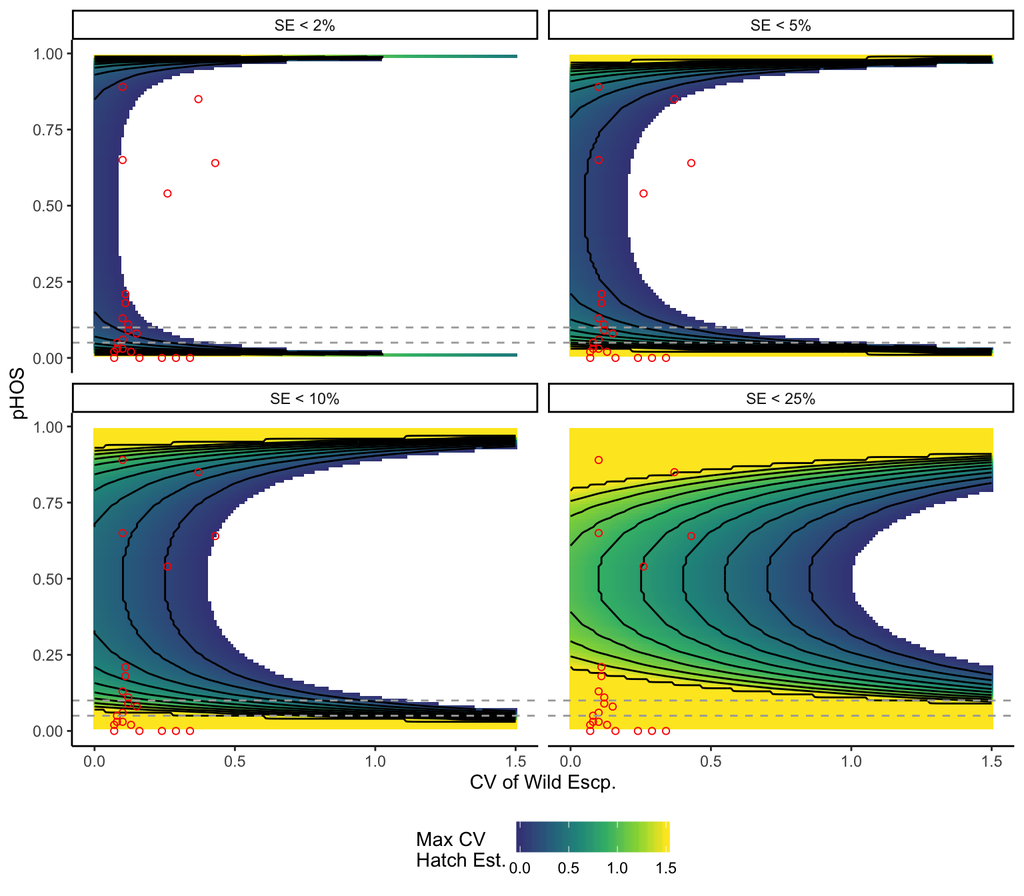

Figure 1: The maximum CV of hatchery abundance estimates that would provide an estimate of pHOS with reasonable precision (below a standard error threshold) for a given level of pHOS and precision of wild escapement. Red points are average observed CV’s of wild escapement and HNC pHOS estimates. Dashed lines show 5% and 10% thresholds for pHOS.

#### Simulation

We modeled the relationship between the number of wild tags detected within a population and the CV of the wild abundance estimate using a log-log model (See et al. 2019; Figure 2) based on results from DABOM from spawn years 2013 - 2019. We assumed that the same relationship holds for hatchery tags detected. For each population, we then used the average CV of the wild abundance estimates over the last several years and average estimated *pHOS* levels from Table 4 to determine the maximum CV of hatchery escapement such that we would meet the various thresholds for *pHOS* standard error. Based on the model shown in Figure 2, we could then estimate how many tags would need to be detected to obtain that CV. From there, we divided that tag number by the weighted average of detected stray rates from Table 5 to estimate how many total tags would need to be deployed at Lower Granite to obtain that number of detections. Those results are shown in Table 6.

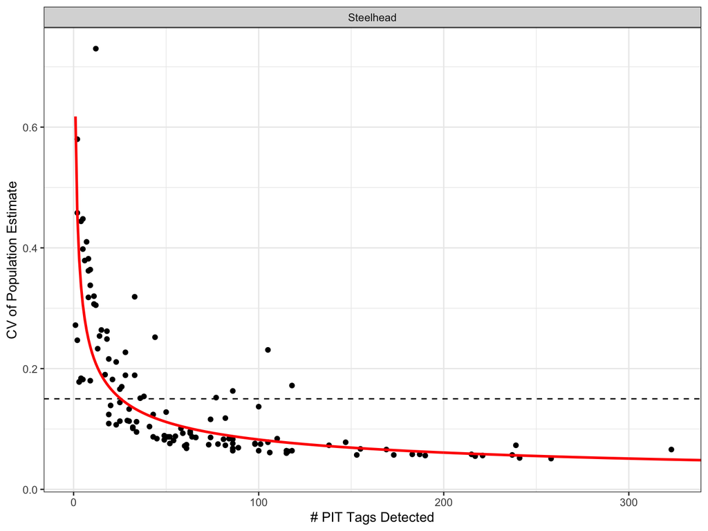

Figure 2: Number of PIT tags observed in a population plotted against the CV of the population estimate. The dashed line shows a CV of 15%, while the red line shows the fitted log-log model.

Table 6: All of the pieces of information that lead to an estimate of the number of tags that must be deployed at Lower Granite Dam to obtain a standard error of pHOS below a set threshold (seThres) for each population. Note that there are four rows for each population, each showing how the number of tags (LGR_tags) changes for a given seThres.

| MPG_DPS | Name | TRT | cvW | pHOS | seThres | maxHcv | n_tags | conv_rate | LGR_tags |
| --- | --- | --- | --- | --- | --- | --- | --- | --- | --- |
| Clearwater | Lower Clearwater River | CRLMA-s | 0.08 | 0.05 | 0.02 | 0.34 | 4 | 0.00029 | 13,793 |
| Clearwater | Lower Clearwater River | CRLMA-s | 0.08 | 0.05 | 0.05 | 0.97 | 1 | 0.00029 | 3,448 |
| Clearwater | Lower Clearwater River | CRLMA-s | 0.08 | 0.05 | 0.10 | 1.50 | 1 | 0.00029 | 3,448 |
| Clearwater | Lower Clearwater River | CRLMA-s | 0.08 | 0.05 | 0.25 | 1.50 | 1 | 0.00029 | 3,448 |
| Clearwater | Lochsa River | CRLOC-s | 0.12 | 0.11 | 0.02 | 0.08 | 108 | 0.00000 | - |
| Clearwater | Lochsa River | CRLOC-s | 0.12 | 0.11 | 0.05 | 0.39 | 3 | 0.00000 | - |
| Clearwater | Lochsa River | CRLOC-s | 0.12 | 0.11 | 0.10 | 0.90 | 1 | 0.00000 | - |
| Clearwater | Lochsa River | CRLOC-s | 0.12 | 0.11 | 0.25 | 1.50 | 1 | 0.00000 | - |
| Clearwater | Lolo Creek | CRLOL-s | 0.10 | 0.65 | 0.02 | - | - | 0.00029 | - |
| Clearwater | Lolo Creek | CRLOL-s | 0.10 | 0.65 | 0.05 | 0.11 | 52 | 0.00029 | 179,310 |
| Clearwater | Lolo Creek | CRLOL-s | 0.10 | 0.65 | 0.10 | 0.33 | 5 | 0.00029 | 17,241 |
| Clearwater | Lolo Creek | CRLOL-s | 0.10 | 0.65 | 0.25 | 0.99 | 1 | 0.00029 | 3,448 |
| Clearwater | Selway River | CRSEL-s | 0.11 | 0.18 | 0.02 | 0.02 | - | 0.00000 | - |
| Clearwater | Selway River | CRSEL-s | 0.11 | 0.18 | 0.05 | 0.22 | 11 | 0.00000 | - |
| Clearwater | Selway River | CRSEL-s | 0.11 | 0.18 | 0.10 | 0.56 | 2 | 0.00000 | - |
| Clearwater | Selway River | CRSEL-s | 0.11 | 0.18 | 0.25 | 1.50 | 1 | 0.00000 | - |
| Clearwater | South Fork Clearwater River | CRSFC-s | 0.10 | 0.89 | 0.02 | 0.10 | 65 | 0.00124 | 52,419 |
| Clearwater | South Fork Clearwater River | CRSFC-s | 0.10 | 0.89 | 0.05 | 0.41 | 3 | 0.00124 | 2,419 |
| Clearwater | South Fork Clearwater River | CRSFC-s | 0.10 | 0.89 | 0.10 | 0.92 | 1 | 0.00124 | 806 |
| Clearwater | South Fork Clearwater River | CRSFC-s | 0.10 | 0.89 | 0.25 | 1.50 | 1 | 0.00124 | 806 |
| Grande Ronde | Joseph Creek | GRJOS-s | 0.07 | 0.02 | 0.02 | 0.95 | 1 | - | - |
| Grande Ronde | Joseph Creek | GRJOS-s | 0.07 | 0.02 | 0.05 | 1.50 | 1 | - | - |
| Grande Ronde | Joseph Creek | GRJOS-s | 0.07 | 0.02 | 0.10 | 1.50 | 1 | - | - |
| Grande Ronde | Joseph Creek | GRJOS-s | 0.07 | 0.02 | 0.25 | 1.50 | 1 | - | - |
| Grande Ronde | Lower Grande Ronde | GRLMT-s | 0.16 | 0.00 | 0.02 | - | - | - | - |
| Grande Ronde | Lower Grande Ronde | GRLMT-s | 0.16 | 0.00 | 0.05 | - | - | - | - |
| Grande Ronde | Lower Grande Ronde | GRLMT-s | 0.16 | 0.00 | 0.10 | - | - | - | - |
| Grande Ronde | Lower Grande Ronde | GRLMT-s | 0.16 | 0.00 | 0.25 | - | - | - | - |
| Grande Ronde | Upper Grande Ronde | GRUMA-s | 0.07 | 0.00 | 0.02 | - | - | - | - |
| Grande Ronde | Upper Grande Ronde | GRUMA-s | 0.07 | 0.00 | 0.05 | - | - | - | - |

[output cut: 58 more lines]

We then examined the proportion of TRT populations that would have reliable estimates of *pHOS* under different tagging numbers at Lower Granite Dam. Assuming a certain number of tags were deployed at Lower Granite, we determined which population would have a standard error of *pHOS* below various thresholds, according to Table 6. We then transformed that into a percent of all TRT populations where we expect to estimate *pHOS* (EXCLUDING those with no observed strays: South Fork Salmon, Grande Ronde River, Selway, Lochsa). This included a total of 10 TRT steelhead populations. In other words, we estimated the proportion of populations that we could obtain a reliable estimate of *pHOS*, **but only of populations for which we have previously observed or measured strays.** This included a total of 10 TRT steelhead populations evaluated. Those results are shown in Figure 3. In other words, the y-axis of Figure 3 only pertains to monitored TRT populations where we have previously observed an HNC stray. Of the 10 populations evaluated, those not shown on a given facet are off the right side of the plot (e.g., more tags need to be deployed at LGR to estimate a precise *pHOS*).

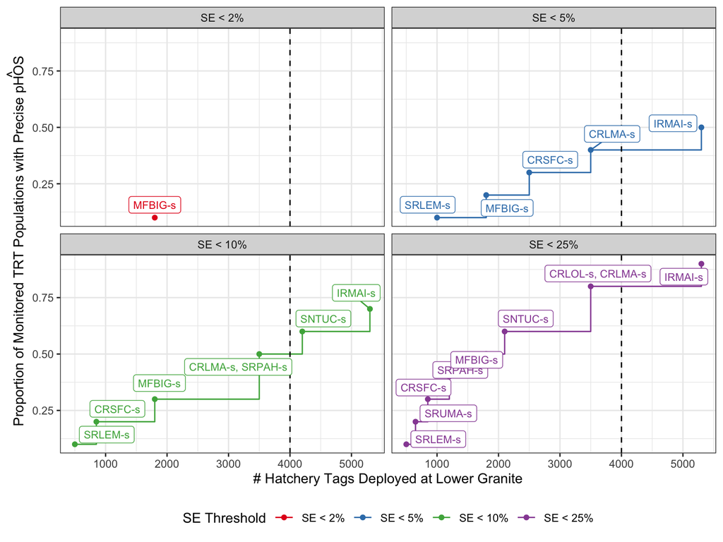

Figure 3: Expected proportion of TRT populations with a reliable estimate of pHOS for a given number of PIT tags deployed at LGR, faceted by pHOS standard error thresholds. Dashed line shows 4,000 tags. Labels depict which additional TRT populations are expected to have reasonable precision of pHOS as the number of tags deployed increases.

# Discussion

Based on the number of detections of hatchery fish tagged as juveniles, relying on observations at IPTDS may not provide the reliable estimate of *pHOS* we are striving for. First, as presented here, without uncertainty around the proportion of each release group tagged (i.e. tagging fraction), there is no way to provide uncertainty with the *pHOS* estimates (recognizing that estimating uncertainty in the tagging fraction is possible by various means). Second, for many of these populations, *pHOS* estimates are based on a handful of detections, so they are very sensitive to small changes in the number of detections. Although estimates produced in this way may be unbiased in general, for any particular population in a particular year the estimates could be very wrong, with no way to capture the uncertainty in that. Finally, as presented here, the straight expansion of observation of hatchery fish tagged as hatchery smolt released does not account for imperfect detection (i.e., detection probability < 1), and although it could be accounted for, is not a trivial task within this framework.

Estimates of *pHOS* based on systematic tagging at LGR and escapement of ad-intact adults, including unclipped hatchery fish and wild fish, may be more reliable, but only include the effects of unclipped hatchery fish and ignore clipped hatchery fish. For some populations, particularly supplementation populations, this may be the majority of the hatchery fish found on the spawning grounds, but that may not be the case for all populations, especially populations occurring in more remote locations. Table 4 shows that for many populations, there are very few HNC tags detected, leading to more uncertainty in the HNC abundance estimates and therefore more uncertainty in the *pHOS* estimates as well. This method may be appropriate for some populations, but the desired number of detections in those populations would need to be accounted for (e.g., when setting the tagging or trapping rate at Lower Granite) and it must be acknowledged that clipped hatchery fish are not accounted for in those *pHOS* estimates.

Finally, tagging clipped hatchery fish at Lower Granite Dam could provide estimates of *pHOS* that are reasonably precise, depending on the threshold for “reasonable” which may vary depending on the estimate of *pHOS*. For some populations with very low incoming stray rates, this method may never provide a reliable estimate of hatchery fish and *pHOS* because we just won’t ever have enough detections. For others, this method could work very well, even with relatively few tags being deployed at Lower Granite (see Table 6). The key for those situations would be ensuring that tags were still deployed as a random, representative sample of the entire hatchery clipped group moving past LGR. Also, determining a reasonable standard error “threshold” for a given level of *pHOS* or population is an important question that must be considered. As an example, are we interested in determining whether the *pHOS* in a given population is above a certain level, say $\geq$ 5% or 10%, that may reduce fitness. In this case, are we okay knowing that *pHOS* is 5% with a confidence interval from 1-9% (SE ~ 2%), or must the SE be less than that? For populations with a larger *pHOS*, say $\geq$ 25%, are we okay with a more relaxed SE like 5%? These questions should be considered more carefully to determine the number of tags that would need to be deployed at LGR to determine *pHOS* across populations in the SRB using this method.

It may be possible to incorporate all of this data and all of these detections into a larger, hierarchical model that borrows information about *pHOS* from populations with more detections (i.e. more precise estimates of wild and hatchery escapement) and spread that out amongst populations with fewer detections. Knowing that these populations are not completely independent, especially when it comes to stray rates, some form of spatial autocorrelation should probably be incorporated into such a smodel. Such a framework may work best across multiple years as well, although if the spatial autocorrelation structure changes, perhaps due to shifting release numbers from various hatcheries, this could confound such an effort.

### Assumptions and Caveats

- That estimates of *pHOS* based on observations of HNC adults at IPTDS are reasonable estimates to start with. They may be underestimating *pHOS*, perhaps to a large degree in some populations, if those populations also experience large numbers of clipped hatchery fish on the spawning grounds. How likely is that? The magnitude of that affect, and which populations it may affect most, should be considered.
- The weighted averages of stray rates in Table 5 also incorporate harvest impacts. Will those impacts (i.e. harvest rate) remain fairly constant across years and populations?

# References

See, K., M. Ackerman, and K. Meier. 2019. Tagging Rate at Lower Granite Dam. Markdown report prepared by Biomark, Inc.

Camacho, C., K. Wright, J. Powell, W. C. Schrader, T. Copeland, M. Ackerman, M. Dobos, M. Corsi, and M. R. Campbell. 2017. Wild adult steelhead and Chinook salmon abundance and composition at Lower Granite Dam, spawn years 2009-2016. Idaho Department of Fish and Game.

Doob, J. L. 1935. The limiting distributions of certain statistics. The Annals of Mathematical Statistics 6(3):160–169.

Orme, R., and R. Kinzer. 2018. Integrated in-stream pit tag detection system operations and maintenance; pit tag based adult escapement estimates for spawn years 2016 and 2017. Nez Perce Tribe.